# Visualizing the Effect of Sample Size on Accuracy:

For and while loops are very important tools, as are if, elif and else statements, so here is an example containing each. Essentially, I wished to create a system that would randomly generate a chosen number of dice rolls and display the frequency that each dice face value appeared. The function of this system was a learning tool to help visualize that as the number of rolls (num_rolls) increases, the data more closely resembles what we would expect from a fair dice. Or more generally, as your sample size increases, your data approximates reality more closely and is less likely to be due to random chance.

```python
import numpy as np
import matplotlib.pyplot as plt
```

To begin, we create the values and lists needed to operate our loops. The number of rolls can be changed here, but we will use 30. An empty list is created so that we can append our random dice rolls to it. The dice list holds all the face values of the dice so we can print out the frequency of each dice value through a for loop.

```python
#Creating necessary values:
dice = [1, 2, 3, 4, 5, 6]
rolls = []
num_rolls = 30
```

Next, we create a while loop which will append a random dice roll to an empty list up until the specified number of rolls is reached.

```python
#Generating the specified number of rolls into a list:
while len(rolls) < num_rolls:
	rolls.append(np.random.randint(1,7))
```

This line visually displays the data generated in a histogram. As the bins approach the same height, the data more closely approximates what we would expect.

```
<function matplotlib.pyplot.show(close=None, block=None)>
```

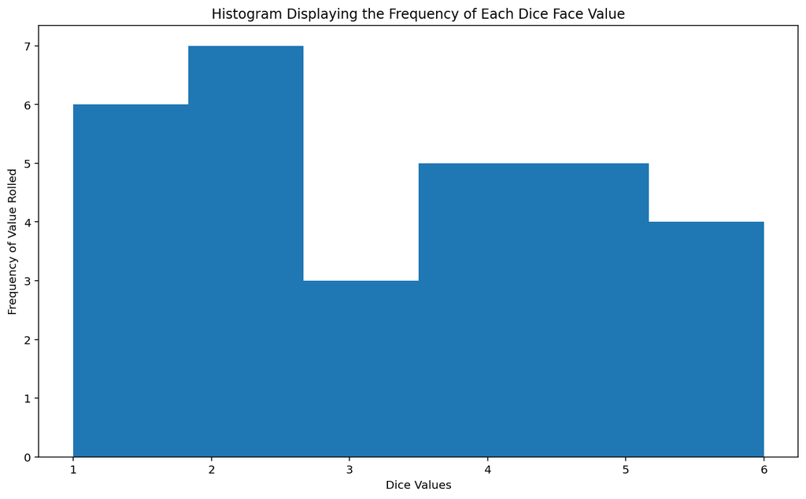

```python
#Visually displaying frequency of face values:
plt.hist(rolls, bins=6)
plt.ylabel('Frequency of Value Rolled')
plt.xlabel('Dice Values')
plt.title('Histogram Displaying the Frequency of Each Dice Face Value')
plt.xticks([1, 2, 3, 4, 5, 6], [1, 2, 3, 4, 5, 6])
plt.show
```

Finally, a for loop was used to display the frequency of each dice face value and how well it approximates the expected.

```python
#Printing the frequencies and accuracy of each face value:
for value in dice:
	print('Frequency of Dice Face Value ' + str(value) + ':')
	frq_value = (rolls.count(value)/num_rolls)*100
	print(str(round(frq_value, 1)) + '%')
	if frq_value >= 16 and frq_value <= 17:
		print('- Approximates Expected Very Well')
	elif frq_value >= 13 and frq_value <= 20:
		print('- Approximates Expected Well')
	else:
		print('- Approximates Expected Poorly')
	print(' ')
```

```
Frequency of Dice Face Value 1:
20.0%
- Approximates Expected Well

Frequency of Dice Face Value 2:
23.3%
- Approximates Expected Poorly

Frequency of Dice Face Value 3:
10.0%
- Approximates Expected Poorly

Frequency of Dice Face Value 4:
16.7%
- Approximates Expected Very Well

Frequency of Dice Face Value 5:
16.7%
- Approximates Expected Very Well

Frequency of Dice Face Value 6:
13.3%
- Approximates Expected Well
```